# GTEx V8 genotype data imputation

Revised from old notebook `20170518_Imputation.ipynb`.

We use UMich imputation server for the task. Limitations of UMich imputation server is mostly that it cannot call indels, and that it is not well versed for hg38 coordinates.

```python
[global]
cwd = "~/Documents/GTExV8"
parameter: genotype = "${cwd!a}/genotypes/GTEx_Analysis_2017-06-05_v8_WholeGenomeSeq_838Indiv_Analysis_Freeze_MAF001_GTonly.vcf.gz"
parameter: chain_file = "hg38ToHg19"


[plink: provides = executable('plink')]
# Download and extract plink2
output: os.path.join(cwd, "utils/plink")
task: workdir = cwd
download:
  https://www.cog-genomics.org/static/bin/plink170509/plink_linux_x86_64.zip
run:
  unzip -o plink_linux_x86_64.zip plink
  mv plink bin/plink
  rm -f plink_linux_x86_64.zip
```

## Genotype missingness summary

Code below calculates missing rate by loci and by individuals. Plots are made to summarize the results.

```python
[summary_1]
# make summary statistics of genotype data
depends: executable("plink")
input: "${genotype!a}"
output: "${cwd!a}/genotype_missing/${input!bnn}.imiss.gz", "${cwd!a}/genotype_missing/${input!bnn}.lmiss.gz"
task: workdir = "${cwd!a}"
run:
    plink --vcf ${input} --missing gz --memory 30000 --threads 8 --out ${output[0]!nn}

[summary_2]
# making genotype summary statistics plot
depends: Py_Module("seaborn")
input: group_by = 1, pattern = "{name}.{ext}"
output: expand_pattern("{_name}.pdf")
task: workdir = "${cwd!a}"
run:
    zcat ${_input} | awk '{print $NF}' > ${_input}.fmiss.tmp
python:
    import os
    import matplotlib.pyplot as plt, seaborn as sns, pandas as pd
    fig, axs = plt.subplots(ncols=2)
    data = pd.read_csv("${_input}.fmiss.tmp", sep = '\t')
    sns.distplot(data["F_MISS"], ax = axs[0], kde = False)
    sns.violinplot(data["F_MISS"], ax = axs[1])
    axs[0].set_title("Missing rate summary")
    fig.savefig(${_output!r})
    os.remove("${_input}.fmiss.tmp")

[summary_3]
# Save summary data to PNG in local folder
input: group_by = 1
output: "img/${_input[0]!bn}.png"
run:
    convert -density 200 ${_input} ${_output}
```

```python
%sosrun summary -b ~/Documents/GTExV8/utils
```

```
Keyboard Interrupt
```

```python
%preview img/GTEx_Analysis_2017-06-05_v8_WholeGenomeSeq_838Indiv_Analysis_Freeze_MAF001_GTonly.imiss.pdf
%preview img/GTEx_Analysis_2017-06-05_v8_WholeGenomeSeq_838Indiv_Analysis_Freeze_MAF001_GTonly.lmiss.pdf
```

> img/GTEx_Analysis_2017-06-05_v8_WholeGenomeSeq_838Indiv_Analysis_Freeze_MAF001_GTonly.lmiss.pdf (14.6 KiB):

[interactive chart not shown]

> img/GTEx_Analysis_2017-06-05_v8_WholeGenomeSeq_838Indiv_Analysis_Freeze_MAF001_GTonly.imiss.pdf (13.9 KiB):

[interactive chart not shown]

Missing rates are small, but should still warrant imputation.

## Data processing for imputation server

Imputation server requires VCF input, by chromosome, each with complete header info. Code chunk below prepares input VCF file for UMich Imputation Server.

```python
[preprocess_0 (utils)]
parameter: lift_over_exec = "${cwd!a}/utils/liftOver"
report: workdir = cwd, output = '/tmp/lift-over.py'
import os
import sys
import tempfile
import subprocess


def lift_over(chrom, pos, strand, map_chain):
    lift_over_exec = ${lift_over_exec!r}

    with tempfile.NamedTemporaryFile() as query:
        q = '\t'.join(['chr' + chrom if not chrom.startswith('chr') else chrom,  # chrom in .chain startswith `chr`
                       str(pos - 1),  # 1-based to 0-based
                       str(pos),      # 1-based to 0-based
                       '.',           # ignored
                       '0',           # ignored
                       strand]) + '\n'
        query.write(q.encode())
        query.seek(0)

        with tempfile.NamedTemporaryFile() as mapped, tempfile.NamedTemporaryFile() as unmapped:
            # $ ./liftOver <oldFile> <map.chain> <newFile> <unMapped>
            cmd = [lift_over_exec, query.name, map_chain, mapped.name, unmapped.name]
            subprocess.Popen(cmd, stdout=subprocess.PIPE, stderr = subprocess.DEVNULL).communicate()[0]
            mapped.seek(0)
            for line in mapped:
                record = line.decode().strip().split('\t')
                return (record[0].replace('chr', ''), record[2], record[5])

def reverse_complement(x):
    reverse_complement_map = str.maketrans('ATGC', 'TACG')
    return x.translate(reverse_complement_map)

for line in sys.stdin:
    if line.startswith('#'):
        print(line.strip())
    else:
        record = line.strip().split('\t')
        new = lift_over(record[0],
                        int(record[1]),  # 1-based pos
                        '+',             # vcf is always forward to reference
                        "${genotype!d}/${chain_file}.over.chain.gz")
        if new:
            new_chrom, new_pos, new_strand = new
            ref = record[3] if new_strand == '+' else reverse_complement(record[3])
            alt = record[4] if new_strand == '+' else reverse_complement(record[4])
            # snp_id = record[2]
            snp_id = '{}_{}_{}_{}'.format(new_chrom, new_pos, ref, alt)
            print('\t'.join([new_chrom, new_pos, snp_id, ref, alt] + record[5:]).strip())


[preprocess_1 (split)]
# split vcf by chroms
chrom = ['chr{}'.format(x + 1) for x in range(22)] + ['chrX'] # there is in fact no Y chrom
input: "${genotype!a}", for_each = ['chrom']
output: ["${cwd!a}/genotype_by_chrom/${input!bnn}.{}.vcf.gz".format(x) for x in chrom], group_by = 1
task: workdir = "${cwd!a}"
run:
  tabix ${input} ${_chrom} --print-header | bgzip > ${_output}

[preprocess_2 (liftover)]
input: group_by = 1, pattern = "{name}.vcf.gz"
output: "${_name}.${chain_file}.vcf.gz"
task: workdir = cwd
bash:
    zcat ${_input}| python /tmp/lift-over.py | gzip --best > ${_output}
```

```python
%sosrun preprocess -J8
```

The issue with liftover is more complicated than I imagined:

https://www.biostars.org/p/266001/

Basically I see variants on one chromesome, after liftover, get moved to multiple chromesomes. An immediate issue is that it messes up the imputation pipeline that requires per-chromosome file (which can be fixed); a longer term concern is that hg19 is not good to use after all.

## Imputation

Imputation was done with [Michigan Imputation Server](https://imputationserver.sph.umich.edu) (MIS) because it uses Haplotype Reference Consortium (32,914 samples) reference panel which is not publicly available otherwise. [Here is how to prepare data](https://imputationserver.sph.umich.edu/start.html#!pages/help) for this service. The prepared files are uploaded to [Michigan imputation server](https://imputationserver.sph.umich.edu).

### Configuration

> img/UMichImputation.png (168.0 KiB):

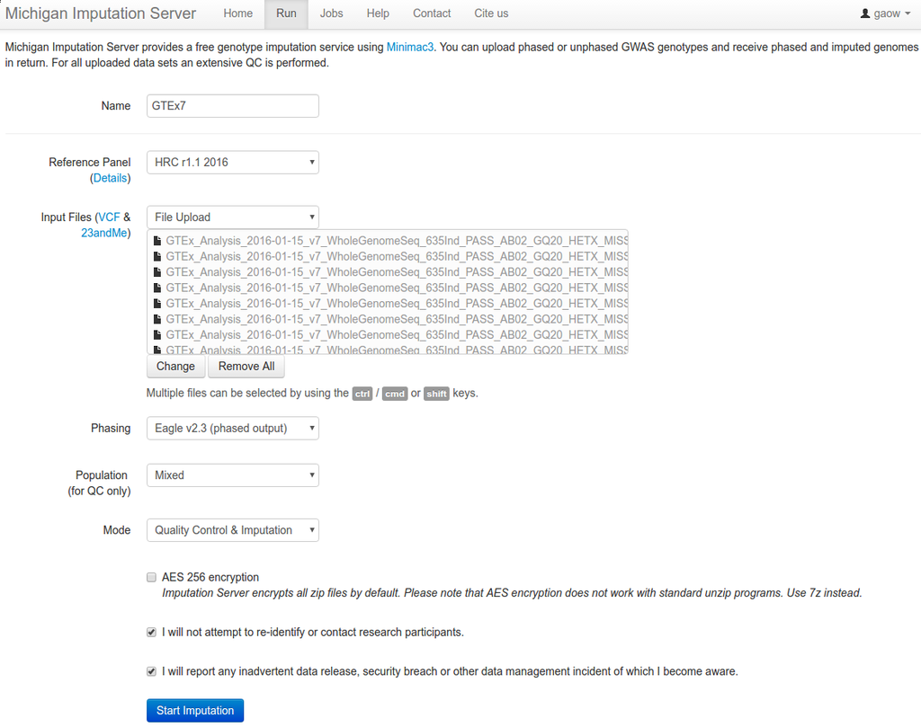

```python
%preview img/UMichImputation.png
```

### Outcome

```python
%preview img/UMichImputationResult.pdf
```

> img/UMichImputationResult.pdf (256.5 KiB):

[interactive chart not shown]

## Imputation result summary

We want to compare the imputation result with the original data to address the following questions:

1. Overlap between original and imputated, and focus on why some are filtered out
2. Filter imputated data removing all imputed sites; also filter by MAF
3. Filter out data having >5% missing in the original
4. Are genotype prediction done for genotypes that are called?
5. Summary of uncertainty in imputed SNPs

```python
%sessioninfo
```

SoS

SoS Version

```
0.9.8.10
```

Copyright © 2016-2020 Gao Wang et al at Stephens Lab, University of Chicago